# Practical Machine Learning Project

## by Hemlata Joshi

**Background**

Using devices such as Jawbone Up, Nike FuelBand, and Fitbit it is now possible to collect a large amount of data about personal activity relatively inexpensively. These type of devices are part of the quantified self movement – a group of enthusiasts who take measurements about themselves regularly to improve their health, to find patterns in their behavior, or because they are tech geeks. One thing that people regularly do is quantify how much of a particular activity they do, but they rarely quantify how well they do it. In this project, your goal will be to use data from accelerometers on the belt, forearm, arm, and dumbell of 6 participants. They were asked to perform barbell lifts correctly and incorrectly in 5 different ways. More information is available from the website here: http://web.archive.org/web/20161224072740/http:/groupware.les.inf.puc-rio.br/har (see the section on the Weight Lifting Exercise Dataset).

**Loading the required packages**

```r
library(caret)
```

```r
library(e1071)
library(rpart)
library(rpart.plot)
library(RColorBrewer)
library(rattle)
library(randomForest)
library(corrplot)
library(gbm)
```

**Importing Data**

```r
pml.training <- read.csv("F:/coursera/practical machine learning/pml-training.csv")
pml.testing <- read.csv("F:/coursera/practical machine learning/pml-testing.csv")
pml.training$classe=as.factor(pml.training$classe)
```

**Summary of Data**

```r
dim(pml.training)
```

```
## [1] 19622   160
```

```r
summary(pml.training)
```

```
##        X          user_name         raw_timestamp_part_1 raw_timestamp_part_2
##  Min.   :    1   Length:19622       Min.   :1.322e+09    Min.   :   294
##  1st Qu.: 4906   Class :character   1st Qu.:1.323e+09    1st Qu.:252912
##  Median : 9812   Mode  :character   Median :1.323e+09    Median :496380
##  Mean   : 9812                      Mean   :1.323e+09    Mean   :500656
##  3rd Qu.:14717                      3rd Qu.:1.323e+09    3rd Qu.:751891
##  Max.   :19622                      Max.   :1.323e+09    Max.   :998801
##
##  cvtd_timestamp      new_window          num_window      roll_belt
##  Length:19622       Length:19622       Min.   :  1.0   Min.   :-28.90
##  Class :character   Class :character   1st Qu.:222.0   1st Qu.:  1.10
##  Mode  :character   Mode  :character   Median :424.0   Median :113.00
##                                        Mean   :430.6   Mean   : 64.41
##                                        3rd Qu.:644.0   3rd Qu.:123.00
##                                        Max.   :864.0   Max.   :162.00
##
##    pitch_belt          yaw_belt       total_accel_belt kurtosis_roll_belt
##  Min.   :-55.8000   Min.   :-180.00   Min.   : 0.00    Length:19622
##  1st Qu.:  1.7600   1st Qu.: -88.30   1st Qu.: 3.00    Class :character
##  Median :  5.2800   Median : -13.00   Median :17.00    Mode  :character
##  Mean   :  0.3053   Mean   : -11.21   Mean   :11.31
##  3rd Qu.: 14.9000   3rd Qu.:  12.90   3rd Qu.:18.00
##  Max.   : 60.3000   Max.   : 179.00   Max.   :29.00
##
##  kurtosis_picth_belt kurtosis_yaw_belt  skewness_roll_belt skewness_roll_belt.1
##  Length:19622        Length:19622       Length:19622       Length:19622
##  Class :character    Class :character   Class :character   Class :character
##  Mode  :character    Mode  :character   Mode  :character   Mode  :character
##
##
##
##
##  skewness_yaw_belt  max_roll_belt     max_picth_belt  max_yaw_belt
##  Length:19622       Min.   :-94.300   Min.   : 3.00   Length:19622
##  Class :character   1st Qu.:-88.000   1st Qu.: 5.00   Class :character
##  Mode  :character   Median : -5.100   Median :18.00   Mode  :character
##                     Mean   : -6.667   Mean   :12.92
##                     3rd Qu.: 18.500   3rd Qu.:19.00
##                     Max.   :180.000   Max.   :30.00
##                     NA's   :19216     NA's   :19216
```

[output cut: 281 more lines]

```
##  Min.   : -7.02000   Min.   : -8.0900   Min.   :-498.00   Min.   :-632.0
##  1st Qu.: -1.46000   1st Qu.: -0.1800   1st Qu.:-178.00   1st Qu.:  57.0
##  Median :  0.03000   Median :  0.0800   Median : -57.00   Median : 201.0
##  Mean   :  0.07517   Mean   :  0.1512   Mean   : -61.65   Mean   : 163.7
##  3rd Qu.:  1.62000   3rd Qu.:  0.4900   3rd Qu.:  76.00   3rd Qu.: 312.0
##  Max.   :311.00000   Max.   :231.0000   Max.   : 477.00   Max.   : 923.0
##
##  accel_forearm_z   magnet_forearm_x  magnet_forearm_y magnet_forearm_z classe
##  Min.   :-446.00   Min.   :-1280.0   Min.   :-896.0   Min.   :-973.0   A:5580
##  1st Qu.:-182.00   1st Qu.: -616.0   1st Qu.:   2.0   1st Qu.: 191.0   B:3797
##  Median : -39.00   Median : -378.0   Median : 591.0   Median : 511.0   C:3422
##  Mean   : -55.29   Mean   : -312.6   Mean   : 380.1   Mean   : 393.6   D:3216
##  3rd Qu.:  26.00   3rd Qu.:  -73.0   3rd Qu.: 737.0   3rd Qu.: 653.0   E:3607
##  Max.   : 291.00   Max.   :  672.0   Max.   :1480.0   Max.   :1090.0
##
```

```r
dim(pml.testing)
```

```
## [1]  20 160
```

```r
summary(pml.testing)
```

```
##        X          user_name         raw_timestamp_part_1 raw_timestamp_part_2
##  Min.   : 1.00   Length:20          Min.   :1.322e+09    Min.   : 36553
##  1st Qu.: 5.75   Class :character   1st Qu.:1.323e+09    1st Qu.:268655
##  Median :10.50   Mode  :character   Median :1.323e+09    Median :530706
##  Mean   :10.50                      Mean   :1.323e+09    Mean   :512167
##  3rd Qu.:15.25                      3rd Qu.:1.323e+09    3rd Qu.:787738
##  Max.   :20.00                      Max.   :1.323e+09    Max.   :920315
##  cvtd_timestamp      new_window          num_window      roll_belt
##  Length:20          Length:20          Min.   : 48.0   Min.   : -5.9200
##  Class :character   Class :character   1st Qu.:250.0   1st Qu.:  0.9075
##  Mode  :character   Mode  :character   Median :384.5   Median :  1.1100
##                                        Mean   :379.6   Mean   : 31.3055
##                                        3rd Qu.:467.0   3rd Qu.: 32.5050
##                                        Max.   :859.0   Max.   :129.0000
##    pitch_belt         yaw_belt      total_accel_belt kurtosis_roll_belt
##  Min.   :-41.600   Min.   :-93.70   Min.   : 2.00    Mode:logical
##  1st Qu.:  3.013   1st Qu.:-88.62   1st Qu.: 3.00    NA's:20
##  Median :  4.655   Median :-87.85   Median : 4.00
##  Mean   :  5.824   Mean   :-59.30   Mean   : 7.55
##  3rd Qu.:  6.135   3rd Qu.:-63.50   3rd Qu.: 8.00
##  Max.   : 27.800   Max.   :162.00   Max.   :21.00
##  kurtosis_picth_belt kurtosis_yaw_belt skewness_roll_belt skewness_roll_belt.1
##  Mode:logical        Mode:logical      Mode:logical       Mode:logical
##  NA's:20             NA's:20           NA's:20            NA's:20
##
##
##
##
##  skewness_yaw_belt max_roll_belt  max_picth_belt max_yaw_belt   min_roll_belt
##  Mode:logical      Mode:logical   Mode:logical   Mode:logical   Mode:logical
##  NA's:20           NA's:20        NA's:20        NA's:20        NA's:20
##
##
##
##
##  min_pitch_belt min_yaw_belt   amplitude_roll_belt amplitude_pitch_belt
##  Mode:logical   Mode:logical   Mode:logical        Mode:logical
##  NA's:20        NA's:20        NA's:20             NA's:20
##
##
```

[output cut: 232 more lines]

```
##  Max.   : 4.2600   Max.   : 1.8000   Max.   : 232.0   Max.   : 406.0
##  accel_forearm_z  magnet_forearm_x magnet_forearm_y magnet_forearm_z
##  Min.   :-282.0   Min.   :-714.0   Min.   :-787.0   Min.   :-32.0
##  1st Qu.:-199.0   1st Qu.:-427.2   1st Qu.:-328.8   1st Qu.:275.2
##  Median :-148.5   Median :-189.5   Median : 487.0   Median :491.5
##  Mean   : -93.7   Mean   :-159.2   Mean   : 191.8   Mean   :460.2
##  3rd Qu.: -31.0   3rd Qu.:  41.5   3rd Qu.: 720.8   3rd Qu.:661.5
##  Max.   : 179.0   Max.   : 532.0   Max.   : 800.0   Max.   :884.0
##    problem_id
##  Min.   : 1.00
##  1st Qu.: 5.75
##  Median :10.50
##  Mean   :10.50
##  3rd Qu.:15.25
##  Max.   :20.00
```

**Preparing Data for Analysis**,

The variables with NA or missing values are removed

```r
#Cleaning of Training data
rvariables=which(colSums(is.na(pml.training)|pml.training=="")>.90*dim(pml.training)[1])
trainingdata=pml.training[, -rvariables]
trainingdata=trainingdata[, -c(1:7)]
dim(trainingdata)
```

```
## [1] 19622    53
```

```r
#Cleaning of Testing data

rvariables=which(colSums(is.na(pml.testing)|pml.testing=="")>.90*dim(pml.testing)[1])
testingdata=pml.testing[, -rvariables]
testingdata=testingdata[, -1]
dim(testingdata)
```

```
## [1] 20 59
```

**Model Building for Prediction**

1. Spliting the training data set into training and testing sets in the .70 and .30 ratio

```r
set.seed(123)
inTrain=createDataPartition(trainingdata$classe, p=.70, list=FALSE)
trainData=trainingdata[inTrain, ]
testData=trainingdata[-inTrain,]
dim(trainData)
```

```
## [1] 13737    53
```

```r
dim(testData)
```

```
## [1] 5885   53
```

2. For analysis we have used three algorithms,
- Decision Tree
- Random Forest and
- Gradient Boosting Method

*1. Decision Tree Method*

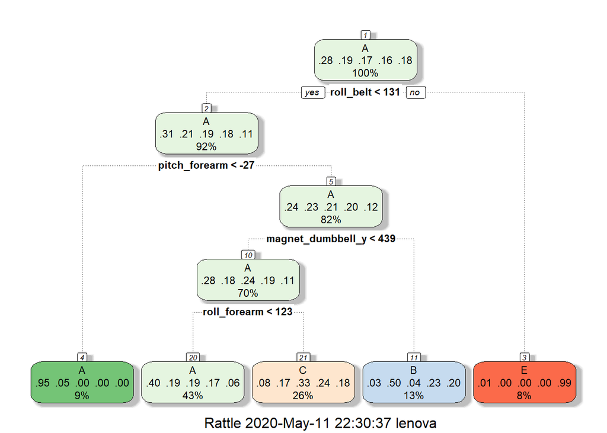

```r
model.ct=train(classe~., data=trainData, method="rpart")
fancyRpartPlot(model.ct$finalModel)
```

```r
trainpred=predict(model.ct, newdata=testData)
testData$classe=as.factor(testData$classe)
table(testData$classe)
```

```
##
##    A    B    C    D    E
## 1674 1139 1026  964 1082
```

```r
table(trainpred)
```

```
## trainpred
##    A    B    C    D    E
## 3047  769 1580    0  489
```

```r
model.ct.conf.mat=confusionMatrix(trainpred, testData$classe)
model.ct.conf.mat$table
```

```
##           Reference
## Prediction    A    B    C    D    E
##          A 1530  464  469  440  144
##          B   28  397   30  169  145
##          C  114  278  527  355  306
##          D    0    0    0    0    0
##          E    2    0    0    0  487
```

```r
model.ct.conf.mat$overall[1]
```

```
##  Accuracy
## 0.4997451
```

*2. Random Forest Method*,

In order to limit the effects of overfitting, and improve the efficicency of the models, we have used the 5-fold cross velidation

```r
trcontrol.rf=trainControl(method="cv", number=5, verboseIter = FALSE)
model.rf=train(classe~., data=trainData, method="rf", trControl=trcontrol.rf, verboseIter=FALSE)
print(model.rf)
```

```
## Random Forest
##
## 13737 samples
##    52 predictor
##     5 classes: 'A', 'B', 'C', 'D', 'E'
##
## No pre-processing
## Resampling: Cross-Validated (5 fold)
## Summary of sample sizes: 10989, 10990, 10991, 10989, 10989
## Resampling results across tuning parameters:
##
##   mtry  Accuracy   Kappa
##    2    0.9895899  0.9868298
##   27    0.9903907  0.9878442
##   52    0.9860960  0.9824100
##
## Accuracy was used to select the optimal model using the largest value.
## The final value used for the model was mtry = 27.
```

```r
model.rf$finalModel
```

```
##
## Call:
##  randomForest(x = x, y = y, mtry = param$mtry, verboseIter = FALSE)
##                Type of random forest: classification
##                      Number of trees: 500
## No. of variables tried at each split: 27
##
##         OOB estimate of  error rate: 0.66%
## Confusion matrix:
##      A    B    C    D    E class.error
## A 3900    4    1    0    1 0.001536098
## B   17 2633    8    0    0 0.009405568
## C    0   12 2375    9    0 0.008764608
## D    0    0   27 2223    2 0.012877442
## E    0    1    3    6 2515 0.003960396
```

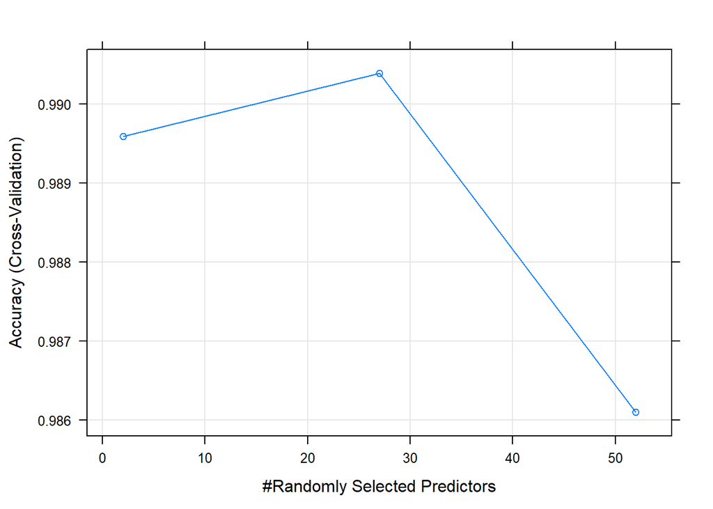

```r
plot(model.rf)
```

```r
trainpred=predict(model.rf, newdata=testData)
model.rf.conf.mat=confusionMatrix(testData$classe, trainpred)
#Confusion matrix and accuracy of the random forest mmodel
model.rf.conf.mat$table
```

```
##           Reference
## Prediction    A    B    C    D    E
##          A 1674    0    0    0    0
##          B    7 1124    8    0    0
##          C    0    5 1019    2    0
##          D    0    0   10  954    0
##          E    0    0    4    5 1073
```

```r
model.rf.conf.mat$overall[1]
```

```
##  Accuracy
## 0.9930331
```

```r
model.rf$finalModel$classes
```

```
## [1] "A" "B" "C" "D" "E"
```

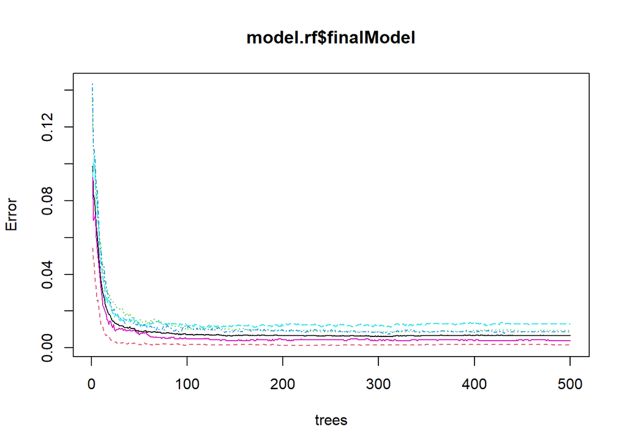

```r
plot(model.rf$finalModel)
```

```r
# Important variables to predict the dependent variable
impvars<- varImp(model.rf)
impvars
```

```
## rf variable importance
##
##   only 20 most important variables shown (out of 52)
##
##                      Overall
## roll_belt             100.00
## pitch_forearm          59.86
## yaw_belt               55.46
## magnet_dumbbell_z      45.56
## pitch_belt             43.39
## magnet_dumbbell_y      42.82
## roll_forearm           36.79
## accel_dumbbell_y       22.16
## roll_dumbbell          20.03
## magnet_dumbbell_x      19.05
## accel_forearm_x        18.07
## magnet_belt_z          16.66
## accel_dumbbell_z       14.34
## accel_belt_z           14.25
## total_accel_dumbbell   13.42
## magnet_belt_y          12.88
## magnet_forearm_z       12.14
## gyros_belt_z           11.91
## yaw_arm                10.94
## roll_arm               10.24
```

*3. Gradient Boosting method*

```r
trcontrol.gbm=trainControl(method = "repeatedcv", number = 5, repeats = 1)
model.gbm=train(classe~., data=trainData, method="gbm", trControl=trcontrol.gbm, verbose=FALSE)
print(model.gbm)
```

```
## Stochastic Gradient Boosting
##
## 13737 samples
##    52 predictor
##     5 classes: 'A', 'B', 'C', 'D', 'E'
##
## No pre-processing
## Resampling: Cross-Validated (5 fold, repeated 1 times)
## Summary of sample sizes: 10989, 10990, 10990, 10989, 10990
## Resampling results across tuning parameters:
##
##   interaction.depth  n.trees  Accuracy   Kappa
##   1                   50      0.7552578  0.6899185
##   1                  100      0.8200475  0.7722455
##   1                  150      0.8525146  0.8133682
##   2                   50      0.8517133  0.8121643
##   2                  100      0.9069666  0.8822669
##   2                  150      0.9316447  0.9135114
##   3                   50      0.8941538  0.8659994
##   3                  100      0.9416909  0.9262278
##   3                  150      0.9592344  0.9484371
##
## Tuning parameter 'shrinkage' was held constant at a value of 0.1
##
## Tuning parameter 'n.minobsinnode' was held constant at a value of 10
## Accuracy was used to select the optimal model using the largest value.
## The final values used for the model were n.trees = 150, interaction.depth =
##  3, shrinkage = 0.1 and n.minobsinnode = 10.
```

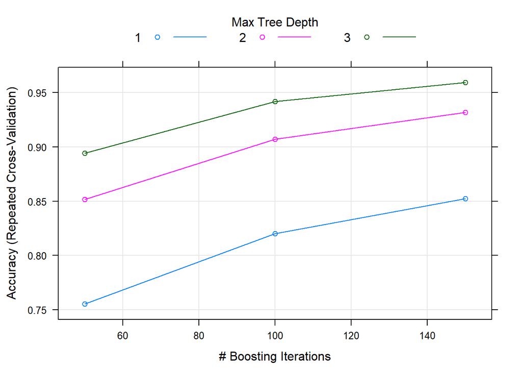

```r
plot(model.gbm)
```

```r
trainpred=predict(model.gbm, newdata=testData)
model.gbm.conf.mat=confusionMatrix(testData$classe, trainpred)
model.gbm.conf.mat$table
```

```
##           Reference
## Prediction    A    B    C    D    E
##          A 1648   16    4    2    4
##          B   33 1069   36    0    1
##          C    0   24  986   16    0
##          D    2    7   25  921    9
##          E    4   11   22   16 1029
```

```r
model.gbm.conf.mat$overall[1]
```

```
##  Accuracy
## 0.9605777
```

** Conclusion** From the above three algorithms, we can see that the accuracy of the Decision Tree is 0.4997451, the accuracy from the Random forest is 0.9930331 and the accuracy from the Gradient Boosing method is 0.9605777. Hence, we found that Random Forest method is the best method among all these methods with accuracy 0.9930331. So, we will use Random Forest method to predict the dependent variable classe for the test data set.

**Prediction**

```r
results <- predict(model.rf,newdata=testingdata)
results
```

```
##  [1] B A B A A E D B A A B C B A E E A B B B
## Levels: A B C D E
```